# Exploring Data, Part 3

Damian Thomas

2016-09-30

## Welcome & Setup

1. Log in to network
2. Update course materials from github
   - https://github.com/wampeh1/ECOG_314
3. Open lecture file in RStudio
   - Lecture5.Rmd

## Midterm

- Schedule

## Homework

- Feedback

## Getting help online

- Cookbook R: http://www.cookbook-r.com/Data_input_and_output/Loading_data_from_a_file/ - recipes for common tasks
- Datacamp Tutorials: https://www.datacamp.com/community/tutorials/importing-data-r-part-two
- Stack Overflow: http://stackoverflow.com/questions/tagged/r - searchable Q&A
- R Bloggers: https://www.r-bloggers.com/read-excel-files-from-r/ - brief posts with examples, links to other sites
- [google](http://www.google.com) - is your friend

Free online books

- Advanced R (http://adv-r.had.co.nz/)
- R for Data Science (http://r4ds.had.co.nz/)

## Resources

http://tryr.codeschool.com/

https://www.rstudio.com/online-learning/#R

http://adv-r.had.co.nz/

https://github.com/hadley/r4ds

## Recap Lecture 3

- Rstudio Interface
- Managing Your Rstudio Session
- R Object types
- R syntax
  - Object creation
  - Object subsetting
  - Expressions
  - Functions
- Reading Data
- Viewing Data
- Running Code - hello.R

## Recap Lecture 4

### Data Set Categories

Data sets fall into 3 major categories:

- *cross sectional*
- *time series*
- *panel or longitudinal*

### Analysis Workflow

This framework is useful for organizing our efforts. In this session we will practice importing data, cleaning data, and transforming it to help us answer (and generate) questions with plots.

### Tasks

- Import data
- Create and alter variables
- Compute summary statistics
- Subset observations
  - and compute aggregates for subsets
- Visualize data
- Merge data sets
- Transform data (restucture)

### Tools

#### Base R

- Import:
  - read.table(), and related functions
- Aggregations:
  - summary()
  - mean()
  - median()
  - sd() & var()
  - min() & max
  - sum()
  - length()
- Transformations
  - ifelse()
  - sub() & gsub()
  - lag()
  - merge()
  - subset()
- Visualization
  - plot()
  - hist()
  - etc.

#### Tidyverse alternatives

- dplyr
- reshape2
- ggplot2

# Lecture 5: Exploring Data, Part 3

## Central Question

Which marvel characters generate the most movie revenue?

The plan is to combine data from several sources and compare the characters based on a series of revenue generation measures.

## Source Data

From Wikipedia (https://en.wikipedia.org/wiki/List_of_Marvel_Cinematic_Universe_films) and IMDb (http://www.imdb.com/list/ls036115103/)

### Avengers team roster

```r
avengers <- read.csv("data/raw/avengers.csv", stringsAsFactors = FALSE)
avengers
```

```
##          codename movies
## 1        Iron Man      3
## 2            Hulk      1
## 3            Thor      2
## 4 Captain America      3
## 5         Hawkeye      0
## 6     Black Widow      0
```

```r
str(avengers)
```

```
## 'data.frame':    6 obs. of  2 variables:
##  $ codename: chr  "Iron Man" "Hulk" "Thor" "Captain America" ...
##  $ movies  : int  3 1 2 3 0 0
```

### Movie Revenue

```r
movies <- read.delim("data/raw/movies.txt", sep = "|", stringsAsFactors = FALSE)
movies
```

```
##                                  title        revenue         released
## 1                             Iron Man   $585,174,222      May 2, 2008
## 2                  The Incredible Hulk   $263,427,551    June 13, 2008
## 3                           Iron Man 2   $623,933,331      May 7, 2010
## 4                                 Thor   $449,326,618      May 6, 2011
## 5   Captain America: The First Avenger   $370,569,774    July 22, 2011
## 6                Marvel's The Avengers $1,519,557,910      May 4, 2012
## 7                           Iron Man 3 $1,215,439,994      May 3, 2013
## 8                 Thor: The Dark World   $644,602,516 November 8, 2013
## 9  Captain America: The Winter Soldier   $714,421,503    April 4, 2014
## 10             Guardians of the Galaxy   $773,312,399   August 1, 2014
## 11             Avengers: Age of Ultron $1,405,413,868      May 1, 2015
## 12                             Ant-Man   $519,445,163    July 17, 2015
## 13          Captain America: Civil War $1,152,745,930      May 6, 2016
```

```r
str(movies)
```

```
## 'data.frame':    13 obs. of  3 variables:
##  $ title   : chr  "Iron Man" "The Incredible Hulk" "Iron Man 2" "Thor" ...
##  $ revenue : chr  "$585,174,222" "$263,427,551" "$623,933,331" "$449,326,618" ...
##  $ released: chr  "May 2, 2008" "June 13, 2008" "May 7, 2010" "May 6, 2011" ...
```

### Screen time

```r
screen_time <- read.delim("data/raw/screen_time.txt", sep = "\t", header = FALSE, stringsAsFactors = FALSE)
head(screen_time, 25)
```

```
##                  V1                                            V2
## 1        Tony Stark                            * IRON MAN <77:15>
## 2        Tony Stark                   * THE INCREDIBLE HULK <:30>
## 3        Tony Stark                          * IRON MAN 2 <61:15>
## 4        Tony Stark                        * THE AVENGERS <32:15>
## 5        Tony Stark                          * IRON MAN 3 <62:15>
## 6        Tony Stark             * AVENGERS: AGE OF ULTRON <27:15>
## 7        Tony Stark          * CAPTAIN AMERICA: CIVIL WAR <33:45>
## 8   Captain America  * CAPTAIN AMERICA: THE FIRST AVENGER <56:30>
## 9   Captain America                        * THE AVENGERS <28:15>
## 10  Captain America    * CAPTAIN AMERICA: THE WINTER SOLDIER <59>
## 11  Captain America             * AVENGERS: AGE OF ULTRON <21:45>
## 12  Captain America                       * ANT-MAN (cameo) <:15>
## 13  Captain America             * CAPTAIN AMERICA: CIVIL WAR <36>
## 14             Thor                                * THOR <43:15>
## 15             Thor                           * THE AVENGERS <18>
## 16             Thor                   * THOR: THE DARK WORLD <35>
## 17             Thor             * AVENGERS: AGE OF ULTRON <13:15>
## 18     Bruce Banner                 * THE INCREDIBLE HULK <51:45>
## 19     Bruce Banner                        * THE AVENGERS <22:15>
## 20     Bruce Banner                    * IRON MAN 3 (cameo) <:45>
## 21     Bruce Banner                * AVENGERS: AGE OF ULTRON <20>
## 22 Natasha Romanoff                           * IRON MAN 2 <9:15>
## 23 Natasha Romanoff                        * THE AVENGERS <24:45>
## 24 Natasha Romanoff * CAPTAIN AMERICA: THE WINTER SOLDIER <24:45>
## 25 Natasha Romanoff                * AVENGERS: AGE OF ULTRON <18>
```

```r
str(screen_time)
```

```
## 'data.frame':    72 obs. of  2 variables:
##  $ V1: chr  "Tony Stark" "Tony Stark" "Tony Stark" "Tony Stark" ...
##  $ V2: chr  "* IRON MAN <77:15>" "* THE INCREDIBLE HULK <:30>" "* IRON MAN 2 <61:15>" "* THE AVENGERS <32:15>" ...
```

### Tidy and Transform

What is the state of the data? Tidy? Ready for plotting and analysis? Not quite.

- avengers data frame
  - Need to reformat codename for merging
- movies data frame
  - The revenue and date variables are text (can’t do math or sort in a meaningful order)
  - No shared identifier for merging
- screen_time data frame
  - No variable names
  - Multiple bits information in single text variable
  - No shared identifier for merging

Code to accomplish these tasks is included in the course repository. We will examine the programs separately

```r
source("clean_avengers_data.R", echo = FALSE)
```

```r
source("clean_movies_data.R", echo = FALSE)
```

```r
source("clean_screen_time_data.R", echo = FALSE)
```

### Visualize

Once we have clean data sets, we can explore with plots and summaries

#### Visualize - Avengers roster

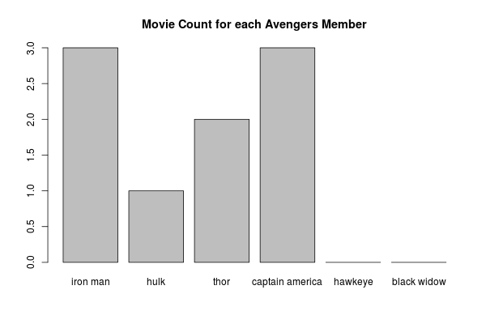

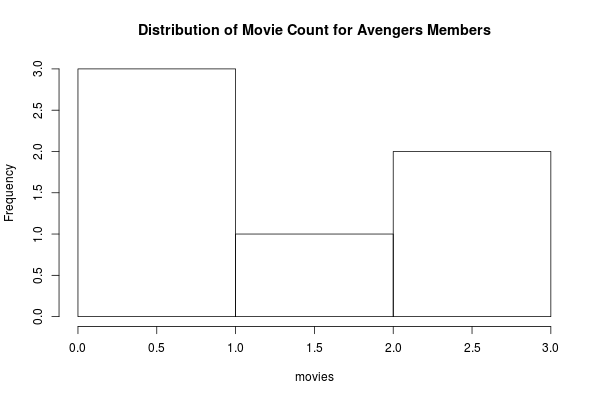

```r
source("plot_avengers_data.R", echo = FALSE)
```

### Questions

- How many movies have been made?
- Average number of movies?
- Who has the most movies?

```r
# Movies made
sum(avengers$movies)

# Average
mean(avengers$movies)

# Most movies, multiple methods
avengers[ avengers$movies == max(avengers$movies), ]      # conditional subset with "["

subset(avengers, avengers$movies == max(avengers$movies)) # conditional subset with function

tail( avengers[ order(avengers$movies),], 3)              # ordered subset or observations
```

#### Answers

- How many movies have been made with the 6 primary avengers? 9
- Average number of movies per member? 1.5
- Who has the most movies?* It’s a tie: iron man, captain america
- Which character is most successful? Hard to tell without more data.

#### Visualize - Movie Revenue

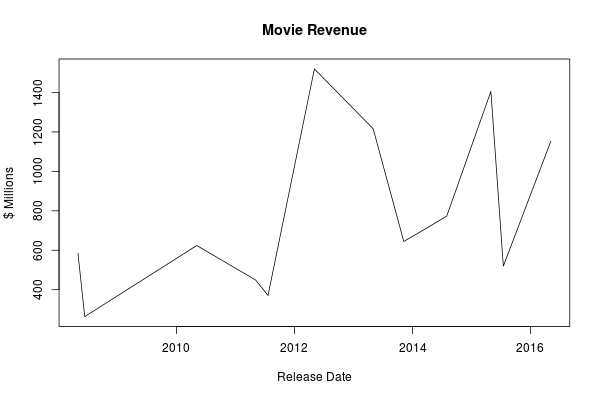

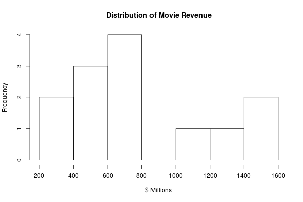

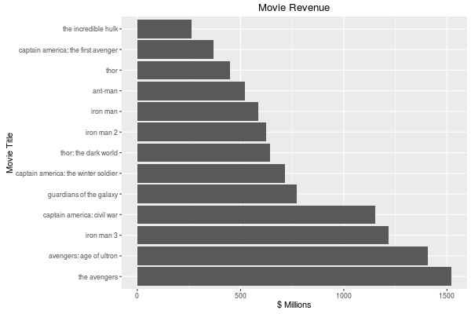

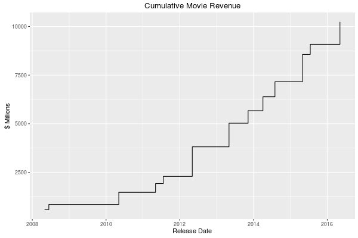

[figure not shown]

```r
source("plot_movies_data.R", echo = FALSE)
```

#### Questions (movie revenues)

- How many movies have been made?
- Average revenue?
- Which movie made the least?

### Transform – aggregate

- Which avenger made the most money?

#### Base R

```r
# Give non-avengers a single label
df <- movies
df[is.na(movies$codename), "codename"] <- "other"

# sum revenue
aggregated <- with(df,

     aggregate(revenue, by = list(codename), FUN = "sum")
)

# results
names(aggregated) <- c("codename", "total_revenue")  # name variables

aggregated
```

```
##          codename total_revenue
## 1 captain america     2237.7372
## 2            hulk      263.4276
## 3        iron man     2424.5475
## 4           other     4217.7293
## 5            thor     1093.9291
```

#### dplyr library functions

Same thing, using dplyr

```r
aggregated <- movies %>%

    mutate(codename = ifelse(is.na(codename), "other", codename)) %>%

    group_by(codename) %>%

    summarise(total_revenue     = sum(revenue),
              total_appearances = n()          ) %>%

    data.frame()

aggregated
```

```
##          codename total_revenue total_appearances
## 1 captain america     2237.7372                 3
## 2            hulk      263.4276                 1
## 3        iron man     2424.5475                 3
## 4           other     4217.7293                 4
## 5            thor     1093.9291                 2
```

#### Answers (movies)

- How many movies have been made?13
- Total revenue? : 10.2 billion
- Average revenue? 787 million
- Which movie made the least? the incredible hulk

#### Visualize - Screen Time

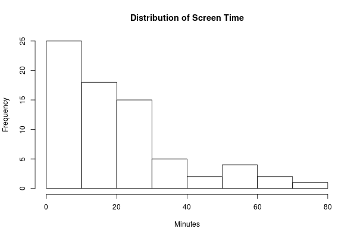

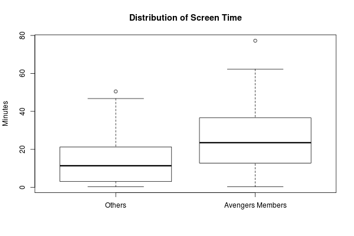

[figure not shown]

```r
source("plot_screen_time_data.R", echo = FALSE)
```

#### Summary Stats - screen time

```r
summary(screen_time)
```

```
##      name              title              minutes           cameo
##  Length:72          Length:72          Min.   : 0.250   Min.   :0.00000
##  Class :character   Class :character   1st Qu.: 5.312   1st Qu.:0.00000
##  Mode  :character   Mode  :character   Median :16.500   Median :0.00000
##                                        Mean   :19.270   Mean   :0.09722
##                                        3rd Qu.:24.917   3rd Qu.:0.00000
##                                        Max.   :77.250   Max.   :1.00000
##    codename           is_avenger
##  Length:72          Min.   :0.0000
##  Class :character   1st Qu.:0.0000
##  Mode  :character   Median :0.0000
##                     Mean   :0.4167
##                     3rd Qu.:1.0000
##                     Max.   :1.0000
```

```r
sd(screen_time$minutes)
```

```
## [1] 17.5684
```

```r
# Standard deviation for avengers
with( subset(screen_time, screen_time$is_avenger == 1),
      sd(minutes)
)
```

```
## [1] 20.88248
```

```r
# average screen time for each avenger
df <- with( subset(screen_time, screen_time$is_avenger == 1),
      aggregate(minutes, by = list(codename), FUN = "mean")
)
names(df) <- c("codename", "average_minutes")
df
```

```
##          codename average_minutes
## 1     black widow        17.76000
## 2 captain america        33.88889
## 3         hawkeye         8.31250
## 4            hulk        23.77083
## 5        iron man        42.07143
## 6            thor        27.59583
```

```r
#  total appearances for each avenger
df <- with( subset(screen_time, screen_time$is_avenger == 1),
      aggregate(codename, by = list(codename), FUN = "length")
)
names(df) <- c("codename", "total_appearances")
df
```

```
##          codename total_appearances
## 1     black widow                 5
## 2 captain america                 6
## 3         hawkeye                 4
## 4            hulk                 4
## 5        iron man                 7
## 6            thor                 4
```

Calculate with dplyr (alternative)

```r
screen_time %>%

    mutate(codename = ifelse(is.na(codename), "other", codename)) %>%

    group_by(codename) %>%

    summarise(total_minutes = sum(minutes),
              total_appearances = n(),
              avgerage_minutes = mean(minutes),
              sd_minutes = sd(minutes)) %>%

    arrange(desc(total_minutes)) %>%

    data.frame()
```

```
##           codename total_minutes total_appearances avgerage_minutes
## 1         iron man     294.50000                 7        42.071429
## 2  captain america     203.33333                 6        33.888889
## 3             thor     110.38333                 4        27.595833
## 4             hulk      95.08333                 4        23.770833
## 5      black widow      88.80000                 5        17.760000
## 6     pepper potts      63.55000                 4        15.887500
## 7             loki      60.25000                 3        20.083333
## 8       scott lang      55.25000                 2        27.625000
## 9      jane foster      46.76667                 2        23.383333
## 10       star-lord      46.75000                 1        46.750000
## 11    james rhodes      45.35000                 5         9.070000
## 12       nick fury      43.80000                 7         6.257143
## 13  winter soldier      42.98333                 4        10.745833
## 14         hawkeye      33.25000                 4         8.312500
```

[output cut: 27 more lines]

## Merging

merge() function

Combine the movie revenue data with the screen time data. Explore how variation in revenue might be related to character screen time.

## Merging - Demonstration

The Merge function combines observations from two data frames based on one (or more) shared identifiers.

```r
?merge
```

#### Example data sets

```r
warm_blooded <- read.table(header=TRUE, text='
animal teeth
cat    30
dog    42
bird   0
ape    32
')

four_legged <- read.table(header=TRUE, text='
animal quiet
cat    TRUE
dog    FALSE
lizard TRUE
')
```

### Basic Merges

Images from [blog](https://blog.codinghorror.com/a-visual-explanation-of-sql-joins/)

Observations with matching identifiers in both

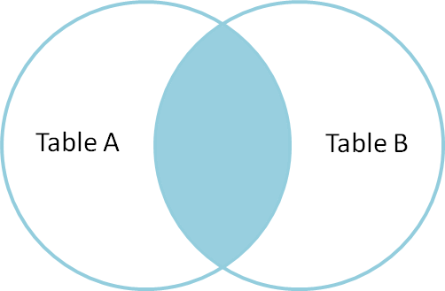

```r
merge(warm_blooded, four_legged)
```

```
##   animal teeth quiet
## 1    cat    30  TRUE
## 2    dog    42 FALSE
```

```r
merge(warm_blooded, four_legged, by = "animal")    # specify the identifier
```

```
##   animal teeth quiet
## 1    cat    30  TRUE
## 2    dog    42 FALSE
```

All Observations from X, matching observations from Y

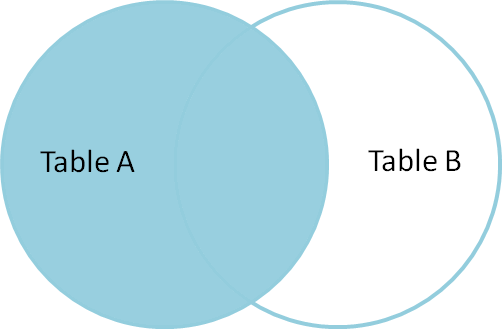

```r
merge(warm_blooded, four_legged, by = "animal", all.x = TRUE)
```

```
##   animal teeth quiet
## 1    ape    32    NA
## 2   bird     0    NA
## 3    cat    30  TRUE
## 4    dog    42 FALSE
```

Or the other way: all observations from Y, matching observations from X

```r
merge(warm_blooded, four_legged, by = "animal", all.y = TRUE)
```

```
##   animal teeth quiet
## 1    cat    30  TRUE
## 2    dog    42 FALSE
## 3 lizard    NA  TRUE
```

All Observations

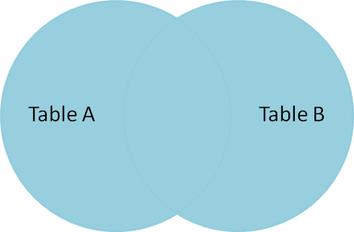

```r
merge(warm_blooded, four_legged, by = "animal", all = TRUE)
```

```
##   animal teeth quiet
## 1    ape    32    NA
## 2   bird     0    NA
## 3    cat    30  TRUE
## 4    dog    42 FALSE
## 5 lizard    NA  TRUE
```

### Non-merges

All Observations from X, excluding matching observations from Y

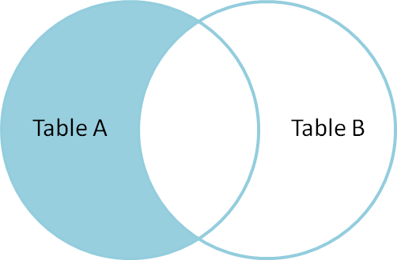

```r
subset(warm_blooded, ! warm_blooded$animal %in% four_legged$animal)
```

```
##   animal teeth
## 3   bird     0
## 4    ape    32
```

All Observations from Y, excluding matching observations from X

```r
subset(four_legged, ! four_legged$animal %in% warm_blooded$animal)
```

```
##   animal quiet
## 3 lizard  TRUE
```

### Complex Merges – Multiple Identifiers

Give the “by” parameter a vecor of column names

```r
person <- read.table(header=TRUE, text='
firstname lastname real
tony      stark    FALSE
tony      montana  FALSE
joe       montana  TRUE
')

occupation <- read.table(header=TRUE, text='
firstname lastname description
tony      stark    engineer
tony      montana  kingpin
joe       montana  quarterback
')

merge(person, occupation, by = c("firstname", "lastname"))
```

```
##   firstname lastname  real description
## 1       joe  montana  TRUE quarterback
## 2      tony  montana FALSE     kingpin
## 3      tony    stark FALSE    engineer
```

What happens if we don’t?

- Multiple observations match
- Duplicate variable names

```r
merge(person, occupation, by = "firstname")
```

```
##   firstname lastname.x  real lastname.y description
## 1       joe    montana  TRUE    montana quarterback
## 2      tony      stark FALSE      stark    engineer
## 3      tony      stark FALSE    montana     kingpin
## 4      tony    montana FALSE      stark    engineer
## 5      tony    montana FALSE    montana     kingpin
```

Probably not what you wanted. This is known as a “many-to-many” join. There are useful applications. Such as computing distances among points

```r
# Metro stations
stations <- read.table(header=TRUE, text='
west  north station     line
20 Q "Dupont Cir"       red
17 K "Farragut North"   red
4  F "Judiciary Sq"     red
')

# Approximate coordinates
stations$x <- stations$west
stations$y <- match(stations$north, LETTERS)

# Many-to-many merge
pairs <- merge(stations, stations, by = "line", suffixes = c("_from", "_to"))

# straight line distance
pairs$distance <- sqrt( (pairs$x_from - pairs$x_to)^2 + (pairs$y_from - pairs$y_to)^2 )

# result
pairs[, c("station_from", "station_to", "distance")]
```

```
##     station_from     station_to  distance
## 1     Dupont Cir     Dupont Cir  0.000000
## 2     Dupont Cir Farragut North  6.708204
## 3     Dupont Cir   Judiciary Sq 19.416488
## 4 Farragut North     Dupont Cir  6.708204
## 5 Farragut North Farragut North  0.000000
## 6 Farragut North   Judiciary Sq 13.928388
## 7   Judiciary Sq     Dupont Cir 19.416488
## 8   Judiciary Sq Farragut North 13.928388
## 9   Judiciary Sq   Judiciary Sq  0.000000
```

## Merging - Applied to the Avengers Question

Compute the total on-screen time per movie

```r
total_screen_time <- aggregate(screen_time$minutes, by = list(screen_time$title), "sum")
names(total_screen_time) <- c("title", "total_minutes")
total_screen_time
```

```
##                                  title total_minutes
## 1                              ant-man      77.28333
## 2              avengers: age of ultron     135.38333
## 3           captain america: civil war     139.71667
## 4   captain america: the first avenger      65.13333
## 5  captain america: the winter soldier     127.98333
## 6              guardians of the galaxy      78.26667
## 7                             iron man     109.00000
## 8                           iron man 2     112.25000
## 9                           iron man 3      91.05000
## 10                        the avengers     185.85000
## 11                 the incredible hulk      79.70000
## 12                                thor     100.85000
## 13                thor: the dark world      85.00000
```

Compute share of screen time per character.

- one-to-many merge: information repeated

```r
df <- merge(screen_time, total_screen_time, by = "title")
df$minutes_share <- df$minutes / df$total_minutes
head(df)
```

```
##                     title            name   minutes cameo        codename
## 1                 ant-man  winter soldier  0.250000     1  winter soldier
## 2                 ant-man captain america  0.250000     1 captain america
## 3                 ant-man      scott lang 50.500000     0      scott lang
## 4                 ant-man      sam wilson  2.033333     0      sam wilson
## 5                 ant-man        hank pym 24.250000     0        hank pym
## 6 avengers: age of ultron    bruce banner 20.333333     0            hulk
##   is_avenger total_minutes minutes_share
## 1          0      77.28333    0.00323485
## 2          1      77.28333    0.00323485
## 3          0      77.28333    0.65343972
## 4          0      77.28333    0.02631011
## 5          0      77.28333    0.31378046
## 6          1     135.38333    0.15019082
```

Compute share of revenue

- one-to-many merge

```r
df <- merge(df, movies[, c("title", "revenue")], by = "title")

df$revenue_share <- df$revenue * df$minutes_share
head(df)
```

```
##                     title            name   minutes cameo        codename
## 1                 ant-man  winter soldier  0.250000     1  winter soldier
## 2                 ant-man captain america  0.250000     1 captain america
## 3                 ant-man      scott lang 50.500000     0      scott lang
## 4                 ant-man      sam wilson  2.033333     0      sam wilson
## 5                 ant-man        hank pym 24.250000     0        hank pym
## 6 avengers: age of ultron    bruce banner 20.333333     0            hulk
##   is_avenger total_minutes minutes_share   revenue revenue_share
## 1          0      77.28333    0.00323485  519.4452      1.680327
## 2          1      77.28333    0.00323485  519.4452      1.680327
## 3          0      77.28333    0.65343972  519.4452    339.426104
## 4          0      77.28333    0.02631011  519.4452     13.666662
## 5          0      77.28333    0.31378046  519.4452    162.991743
## 6          1     135.38333    0.15019082 1405.4139    211.080256
```

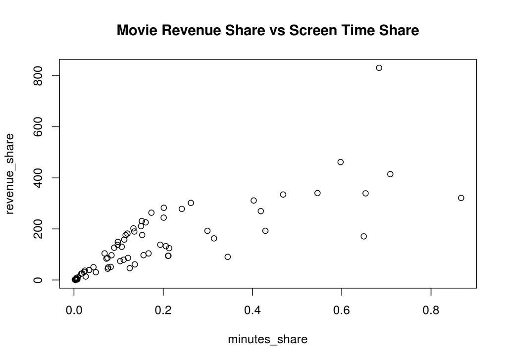

```r
with(df,

     plot(minutes_share,
          revenue_share,
          main = "Movie Revenue Share vs Screen Time Share")

)
```

```r
average_share <- aggregate(df$revenue_share, by = list(df$codename), "mean")
names(average_share) <- c("codename", "average_revenue")

average_share[order(-average_share$average_revenue),]
```

```
##           codename average_revenue
## 17       star-lord       461.91254
## 9         iron man       344.69100
## 5           gamora       311.39986
## 3  captain america       236.11752
## 16      scott lang       189.30822
## 18            thor       187.42948
## 6         hank pym       162.99174
## 11     jane foster       143.93574
## 8             hulk       143.51501
## 2      black widow       135.77054
## 12            loki       134.39301
## 14    pepper potts       125.79358
## 1       betty ross        90.72881
## 7          hawkeye        75.99389
## 20  winter soldier        74.51695
## 10    james rhodes        70.98931
## 19  wanda maximoff        70.64159
## 15      sam wilson        46.90731
## 13       nick fury        43.64311
## 4      erik selvig        35.81954
```